# Motivations et éléments théoriques

J'ai écrit ce cahier dans l'objectif de présenter une interprétation géométrique et concrète du gradient d'un champ scalaire.

Pour cela, je me place dans le cas d'un champ scalaire de deux variables exprimées en coordonnées cartésiennes.

Je suppose que le lecteur est déjà familier avec les bases en calcul différentiel, mais je me permets toutefois quelques petits rappels qui me semble être essentiel pour mon sujet...

Dans la suite, $f$ désignera un champ scalaire défini sur un domaine $\Omega \subset \mathbb{R}^2$.

En algèbre linéaire, on s'abstient de flécher les vecteurs, sauf si le vecteur est défini par deux points (origine et extrémité). Cela allège les écritures. Nous adoptons cela dans la suite. Pour distinguer le point avec le vecteur, nous utilserons la majuscule pour le point, la mniscule pour le vecteur.

Dans ce cahier, j'utilise aussi l'opération $M+v$ avec $M$ un point et $v$ un vecteur. Cette opération consiste à définir l'unique point $N=M+v$ tel que $\overrightarrow{MN}=v$.

## Gradient d'un champ scalaire

**Le gradient d'un champ scalaire** au point $M$, noté $\nabla f(M)$, est l'unique vecteur vérifiant pour tout $h$ la relation :

$$df(M).h=\nabla f(M).h$$

On a, en coordonnées cartésiennes :

$$\nabla f(M)=\begin{pmatrix} \dfrac{\partial f(M)}{\partial x}\\ \dfrac{\partial f(M)}{\partial y}\\ \end{pmatrix}$$

Le gradient d'un champ scalaire est de par sa nature même un champ vectoriel.

Pour alléger l'écriture, on notera souvent :

$$\nabla f=\begin{pmatrix} \dfrac{\partial f}{\partial x}\\ \dfrac{\partial f}{\partial y}\\ \end{pmatrix}$$

## Gradient et lignes de niveaux

Soit $f$ un champ scalaire et $\mathcal{C}_{\alpha}$ la ligne de niveau $f(x;y)=\alpha$.

Soit $\gamma(t)=(x(t),y(t))$ un paramétrage de cette ligne de niveau et $g$ la fonction réelle définie par $g(t)=f(\gamma(t))-\alpha$.

Clairement, $g(t)=0$ pour tout $t$, donc $g'(t)=0$ également.

Or, par dérivation de fonction composée, on a : $g'(t)=\nabla f(\gamma(t)).\gamma'(t)$, donc $\nabla f(\gamma(t)).\gamma'(t)=0$ et donc $\nabla f(\gamma(t))\perp\gamma'(t)$.

Comme le vecteur $\gamma'(t)$ dirige la tangente à la courbe de niveau, on peut donc énoncer :

**En tout point $M(x,y)$ de l'un ligne de niveau d'un champ scalaire $f$, la normale à la ligne de niveau est dirigée par $\nabla f(M)$.**

## Gradient et plus forte pente

Le développement limité à l'ordre 1, sur un voisinage de $M$ dans la direction de $v$ s'écrit :

\begin{align*} f(M+tv)&=f(M)+\langle\nabla f(M) , tv\rangle + t\varepsilon(t)\\ &=f(M)+t\langle\nabla f(M) , v\rangle + t\varepsilon(t)\\ \end{align*}

avec : $\lim_{t\to 0}\varepsilon(t)=0$

Plus particulièrement, on dira que le vecteur $d$ est **une direction de descente** s'il existe $\eta>0$ tel que : $f(M+t_2d)\leq f(M+t_1d)\leq f(M)$ pour tous réels $(t_1,t_2)\in]0,\eta]^2$ avec $t_1<t_2$, signifiant que la fonction $t\mapsto f(M+td)$ est décroissante lorsque $t$ varie dans l'intervalle $[0,\eta]$, pour des valeurs donc de $t$ proche de $0$.

On a :

\begin{align*} f(M+td)&=f(M)+ t\langle\nabla f(M) , d\rangle + t\varepsilon(t)\\ \end{align*}

Ainsi, lorsque $t$ est positif, petit et tend vers $0$, on obtient :

$$\langle\nabla f(M) , d\rangle > 0 \Rightarrow f(M+td) > f(M)$$

et également :

$$\langle\nabla f(M) , d\rangle < 0 \Rightarrow f(M+td) < f(M)$$

Autrement dit :

- Si $\langle\nabla f(M) , d\rangle > 0$, alors $f$ est croissante dans la direction de $d$
- Inversement, si $\langle\nabla f(M) , d\rangle < 0$, alors $f$ est décroissante dans la direction de $d$. Dans ce cas, on dira que $d$ est une direction de descente de $f$.

**On a retiendra, pour résumer, que $d$ est une direction de descente si et seulement si $\langle\nabla f(x) , d\rangle < 0$, signifiant que $t\mapsto f(M+td)$ décroit localement.**

Rappelons l'inégalité de **Cauchy-Schwarz**. Pour tous vecteurs $u$ et $v$, on a :

$$|\langle u, v\rangle| \leq \|u\| \|v\|$$

L'égalité étant réalisée si et seulement si $x$ et $y$ sont colinéaires.

Soit $d$ un vecteur tel que $\|d\|=\|\nabla f(M)\|$. En utilisant l'inégalité de Cauchy-Schwarz, on a :

$$-\|\nabla f(M)\|^2\leq \langle \nabla f(M),d\rangle \leq \|\nabla f(M)\|^2$$

En utilisant à nouveau $f(x+td)=f(x)+ t\langle\nabla f(x) , d\rangle + t\varepsilon(t)$, toujours avec $t>0$, on obtient :

**"Pour toutes les directions données par les vecteurs de norme fixée égale à $\|\nabla f(x)\|$, la direction du gradient, dans son sens, donne l'accroissement le plus fort, et à contre sens donne la direction de descente la plus forte sur un voisinage de $M$."**

# Mon interprétation géométrique et concrète

Compte tenu de ce qui précède, voici comment je pourrais raconté le gradient, de manière concrète.

Imaginons que je suis à Courchevel, tout en haut du domaine skiable, par une belle journée de grand beau, neige fraiche, piste dammée, chaussé de ma belle paire de skis "all mountain" dernière génération.

J'aime les sensations et je souhaite être le premier arrivé au resto en bas, avec mon burger, mes frites et ma pinte de bière IPA, posé, avant tout le monde.

Pour cela, je vais descendre la piste, à fond la caisse, mais en gardant en tête l'histoire de ce fameux gradient. Alors, quitte à faire plein de beaux virages, ou de belle courbes sur la carre, en carvant au maximum, je vais suivre toujours le chemin qui emprunte la plus forte pente. Il me suffit de suivre la direction du gradient d'altitude, dans son sens opposé.

Cette petite histoire, c'est la même qui sera racontée en mécanique des fluides ou en transfert thermique. C'est la même qui sera racontée en optimisation, en particulier pour l'algorithme du gradient pour la minisation d'une fonctionnelle... Le "Deep learning", tellement à la mode, se base sur ce principe de descente le long du gradient.

Pour illustrer cette histoire, je vais faire des petites animations, en utilisant le langage Julia pour la programmation. Chaque animation est construite de la manière suivante :

- Je dessine la surface représentative du champ $f$. On obtient un dessin en $3D$ qui représente notre montagne
- Je trace la trajectoire d'un point qui descent en suivant la direction du gradient, dans son sens opposé (pour perdre en altitude).

A partir d'un point $P(M,f(M))$ de la surface avec $M(x,y)\in \Omega$, on se déplace petit à petit en suivant le gradient vers le sens décroissant. L'algorithme est basé sur le procédé itératif suivant :

\begin{align*} P_n&=(M_n,f(M_n))\\ M_{n+1}& \leftarrow M_n + \eta\nabla f(M_n)\\ P_{n+1}& \leftarrow (M_{n+1},f(M_{n+1}))\\ \end{align*}

Il faudra éviter les points critiques en lesquels $\nabla f$ est nul, car alors le procédé ne permet plus d'avancer...

Le facteur $\eta$ s'appelle le pas de descente. Il faut que ce pas soit petit, car on se souvient que tout ce qui a été dit sur la descente suivant le gradient n'est vrai que localement autour du point $M$, sur un voisinage restreint.

Pour faire un joli dessin, je remplace parfois $\nabla f(M_n)$ par :

$$\dfrac{\nabla f(M_n)}{\|\nabla f(M_n)\|}$$

Pourquoi ? déjà parce que je ne modifie ni la direction ni le sens du gradient, ensuite, cela me permet de suivre un vecteur de norme constante. Cela ne sera toutefois pas possible si le gradient s'annule...

J'ai dit "joli", oui, c'est vrai, c'est subjectif... mais celles et ceux qui ne vont pas trouver mes dessins et animations jolis peuvent toujours me proposer des améliorations, ou passer leur chemin.

```julia
using Plots;
gr()
using LinearAlgebra;
```

# Simulations

Dans les simulations ci-dessous, le principe est simple. Je suis la petite boule orange, et le resto avec mon burger-frite + pinte m'attend au niveau de l'étoile... et boum, je pars en suivant la direction du gradient, dans son sens opposé.. le tracé est fait sur l'image en 3d le long de la surface, puis sur l'image en 2d sur laquelle la même simulation est représenté, mais projeté dans le plan dans lequel les lignes de niveau sont tracées.

## Exemple 1

Dans cet exemple, la surface est définie comme étant la surface représentative du champ :

$$f(x,y)=x^2+3y^2$$

Dans ce cas, on a :

$$\nabla f=\begin{pmatrix} 2x\\ 6y\\ \end{pmatrix}$$

Le seul point critique est le point $(0,0)$ en lequel le champ présente un minimum global.

On va faire deux simulation pour cet exemple.

Dans la première, on prend un pas un peu trop gros, signifiant que lorsqu'on suit notre gradient, on y va vraiment un peu trop fort... il va falloir changer de direction de manière asse brutale, surtout su la fin du parcours...(flexion, planter du baton, extension... à la Jean Claude Dus...)

Dans la deuxième simulation, on prend un pas plus petit, la courbe suivie sera plus douce, plus belle...(en carving) en permanence on se recale sur le gradient...

### exemple 1 : simulation 1

```
┌ Info: Saved animation to
│   fn = D:\Users\guilhot\Documents\0MATHS\0COURS\52 OPTIMISATION\surf1a.gif
└ @ Plots D:\Users\guilhot\.julia\packages\Plots\SVksJ\src\animation.jl:104
```

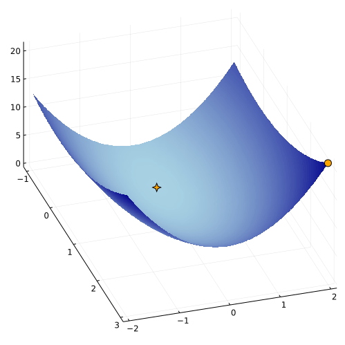

```julia
Nx=50;Ny=50;
X=range(-1,stop=3,length=Nx);Y=range(-2,stop=2,length=Nx)
function f1(x,y)
    x^2+3*y^2
end
function df1(x,y)
    [2*x ; 6*y]
end
function u1(x,y)
    df1(x,y)
#    df1(x,y)/norm(df1(x,y))
end

pas=-0.25

M0=[3;2]

P0=[M0[1];M0[2];f1(M0[1],M0[2])]

surf=surface(X, Y, f1,c=:blues,legend=false,camera=(65,65),size=(500,500))
surf=scatter!([P0[1]],[P0[2]],[P0[3]],c=:orange, marker=:circ,markersize=6)
surf=scatter!([0],[0],[0],c=:orange, marker=:star4,markersize=6)
M1=M0
anim=@animate for k in 1:10
    M1=M0
    P1=[M1[1];M1[2];f1(M1[1],M1[2])]
    surf=plot!([P0[1],P1[1]],[P0[2],P1[2]],[P0[3],P1[3]], c=:black)
    M0=M0+pas*u1(M0[1],M0[2])
    P0=P1
end

gif(anim,"surf1a.gif",fps = 2)
```

```
┌ Info: Saved animation to
│   fn = D:\Users\guilhot\Documents\0MATHS\0COURS\52 OPTIMISATION\niv1a.gif
└ @ Plots D:\Users\guilhot\.julia\packages\Plots\SVksJ\src\animation.jl:104
```

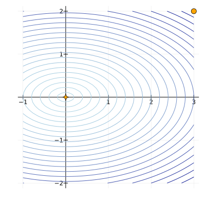

```julia
M0=[3;2]
lev=[(i/5)^2 for i in 0:30]
niv=contour(X, Y, f1, c=:blues,xticks=-1:1:3,yticks=-2:1:2,levels=lev,legend=false,
   framestyle=:origin)
niv=scatter!([M0[1]],[M0[2]],c=:orange, marker=:circ, markersize=6)
niv=scatter!([0],[0],c=:orange, marker=:star4, markersize=6)

M1=M0
anim=@animate for k in 1:10
    niv=plot!([M0[1],M1[1]],[M0[2],M1[2]],c=:black , line=:arrow,size=(400,400))
    M0=M1
    M1=M0+pas*u1(M0[1],M0[2])
end

gif(anim,"niv1a.gif",fps = 2)
```

### exemple 1 : simulation 2

```
┌ Info: Saved animation to
│   fn = D:\Users\guilhot\Documents\0MATHS\0COURS\52 OPTIMISATION\surf1b.gif
└ @ Plots D:\Users\guilhot\.julia\packages\Plots\SVksJ\src\animation.jl:104
```

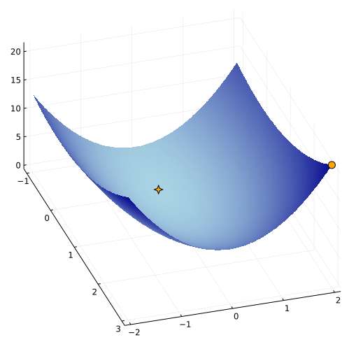

```julia
Nx=50;Ny=50;
X=range(-1,stop=3,length=Nx);Y=range(-2,stop=2,length=Nx)
function f1(x,y)
    x^2+3*y^2
end
function df1(x,y)
    [2*x ; 6*y]
end
function u1(x,y)
    df1(x,y)/norm(df1(x,y))
end

pas=-0.2

M0=[3;2]

P0=[M0[1];M0[2];f1(M0[1],M0[2])]

surf=surface(X, Y, f1,c=:blues,legend=false,camera=(65,65),size=(500,500))
surf=scatter!([P0[1]],[P0[2]],[P0[3]],c=:orange, marker=:circ,markersize=6)
surf=scatter!([0],[0],[0],c=:orange, marker=:star4,markersize=6)
M1=M0
anim=@animate for k in 1:25
    M1=M0
    P1=[M1[1];M1[2];f1(M1[1],M1[2])]
    surf=plot!([P0[1],P1[1]],[P0[2],P1[2]],[P0[3],P1[3]], c=:black)
    M0=M0+pas*u1(M0[1],M0[2])
    P0=P1
end

gif(anim,"surf1b.gif",fps = 2)
```

```
┌ Info: Saved animation to
│   fn = D:\Users\guilhot\Documents\0MATHS\0COURS\52 OPTIMISATION\niv1b.gif
└ @ Plots D:\Users\guilhot\.julia\packages\Plots\SVksJ\src\animation.jl:104
```

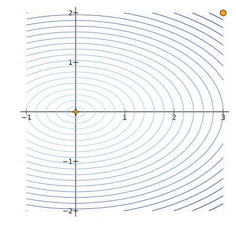

```julia
M0=[3;2]
lev=[(i/5)^2 for i in 0:30]
niv=contour(X, Y, f1, c=:blues,xticks=-1:1:3,yticks=-2:1:2,levels=lev,legend=false,
   framestyle=:origin)
niv=scatter!([M0[1]],[M0[2]],c=:orange, marker=:circ, markersize=6)
niv=scatter!([0],[0],c=:orange, marker=:star4, markersize=6)

M1=M0
anim=@animate for k in 1:20
    niv=plot!([M0[1],M1[1]],[M0[2],M1[2]],c=:black , line=:arrow,size=(400,400))
    M0=M1
    M1=M0+pas*u1(M0[1],M0[2])
end

gif(anim,"niv1b.gif",fps = 2)
```

## Exemple 2

Dans cet exemple, la surface est définie comme étant la surface représentative du champ :

$$f(x,y)=x^2-y^2$$

Dans ce cas, on a :

$$\nabla f=\begin{pmatrix} 2x\\ -2y\\ \end{pmatrix}$$

Le seul point critique est le point $(0,0)$ en lequel le champ présente un point col.

On a envie ici de faire deux simulations. Dans la première, on se débrouille pour partir un peu en décalé, afin d'éviter sur la trajectoire le point critique... dans la deuxième, on va mieux viser...

### exemple 2 : simulation 1

```
┌ Info: Saved animation to
│   fn = D:\Users\guilhot\Documents\0MATHS\0COURS\52 OPTIMISATION\surf2a.gif
└ @ Plots D:\Users\guilhot\.julia\packages\Plots\SVksJ\src\animation.jl:104
```

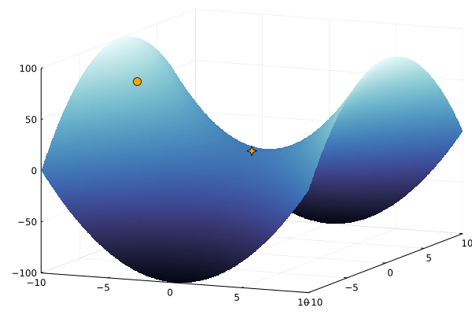

```julia
Nx=50;Ny=50;
X=range(-10,stop=10,length=Nx);Y=range(-10,stop=10,length=Nx)
function f2(x,y)
    x^2-y^2
end
function df2(x,y)
    [2*x ; -2*y]
end
function u2(x,y)
    df2(x,y)/norm(df2(x,y))
end

pas=-0.4

M0=[-8;-1]

P0=[M0[1],M0[2],f2(M0[1],M0[2])]

surf=surface(X, Y, f2,c=:ice,legend=false,camera=(30,35),size=(600,400),
    xlims=(-10,10),ylims=(-10,10),zlims=(-100,100))
surf=scatter!([P0[1]],[P0[2]],[P0[3]],c=:orange, marker=:circ,markersize=6)
surf=scatter!([0],[0],[0],c=:orange, marker=:star4,markersize=6)

anim=@animate for k in 1:40
    M1=M0
    P1=[M1[1];M1[2];f2(M1[1],M1[2])]
    surf=plot!([P0[1],P1[1]],[P0[2],P1[2]],[P0[3],P1[3]], c=:black)
    M0=M0+pas*u2(M0[1],M0[2])
    P0=P1
end

gif(anim,"surf2a.gif",fps = 5)
```

```
┌ Info: Saved animation to
│   fn = D:\Users\guilhot\Documents\0MATHS\0COURS\52 OPTIMISATION\niv2a.gif
└ @ Plots D:\Users\guilhot\.julia\packages\Plots\SVksJ\src\animation.jl:104
```

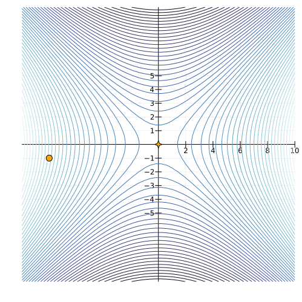

```julia
M0=[-8;-1]
niv=contour(X, Y, f2, c=:ice,xticks=0:2:10,yticks=-5:1:5,levels=50,legend=false,
    xlims=(-10,10),ylims=(-10,10),size=(500,500),framestyle=:origin)
niv=scatter!([M0[1]],[M0[2]],c=:orange, marker=:circ, markersize=6)
niv=scatter!([0],[0],c=:orange, marker=:star4, markersize=6)
M1=M0
anim=@animate for k in 1:50
    niv=plot!([M0[1],M1[1]],[M0[2],M1[2]], c=:black , line=:arrow)
    M0=M1
    M1=M0+pas*u2(M0[1],M0[2])
end

gif(anim,"niv2a.gif",fps = 5)
```

### exemple 2 : simulation 2

```
┌ Info: Saved animation to
│   fn = D:\Users\guilhot\Documents\0MATHS\0COURS\52 OPTIMISATION\surf2b.gif
└ @ Plots D:\Users\guilhot\.julia\packages\Plots\SVksJ\src\animation.jl:104
```

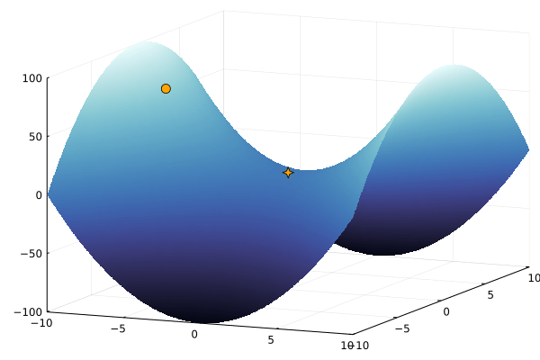

```julia
Nx=50;Ny=50;
X=range(-10,stop=10,length=Nx);Y=range(-10,stop=10,length=Nx)
function f2(x,y)
    x^2-y^2
end
function df2(x,y)
    [2*x ; -2*y]
end
function u2(x,y)
#    df2(x,y)
    df2(x,y)/norm(df2(x,y))
end

pas=-0.4

M0=[-8;0]

P0=[M0[1],M0[2],f2(M0[1],M0[2])]

surf=surface(X, Y, f2,c=:ice,legend=false,camera=(30,35),size=(600,400),
    xlims=(-10,10),ylims=(-10,10),zlims=(-100,100))
surf=scatter!([P0[1]],[P0[2]],[P0[3]],c=:orange, marker=:circ,markersize=6)
surf=scatter!([0],[0],[0],c=:orange, marker=:star4,markersize=6)

anim=@animate for k in 1:40
    M1=M0
    P1=[M1[1];M1[2];f2(M1[1],M1[2])]
    surf=plot!([P0[1],P1[1]],[P0[2],P1[2]],[P0[3],P1[3]], c=:black)
    M0=M0+pas*u2(M0[1],M0[2])
    P0=P1
end

gif(anim,"surf2b.gif",fps = 5)
```

```
┌ Info: Saved animation to
│   fn = D:\Users\guilhot\Documents\0MATHS\0COURS\52 OPTIMISATION\niv2b.gif
└ @ Plots D:\Users\guilhot\.julia\packages\Plots\SVksJ\src\animation.jl:104
```

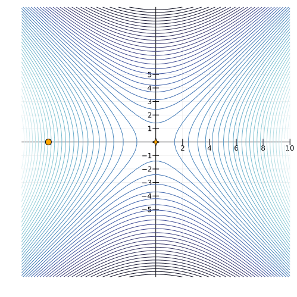

```julia
M0=[-8;0]
niv=contour(X, Y, f2, c=:ice,xticks=0:2:10,yticks=-5:1:5,levels=50,legend=false,
    xlims=(-10,10),ylims=(-10,10),size=(500,500),framestyle=:origin)
niv=scatter!([M0[1]],[M0[2]],c=:orange, marker=:circ, markersize=6)
niv=scatter!([0],[0],c=:orange, marker=:star4, markersize=6)
M1=M0
anim=@animate for k in 1:50
    niv=plot!([M0[1],M1[1]],[M0[2],M1[2]], c=:black , line=:arrow)
    M0=M1
    M1=M0+pas*u2(M0[1],M0[2])
end

gif(anim,"niv2b.gif",fps = 5)
```

## Exemple 3

Cette fois-ci, on regarde :

$$f(x,y)=y\exp(-x^2-y^2)$$

Dans ce cas, on a : $$\nabla f=\begin{pmatrix} -2xy\exp(x^2-y^2)\\ \exp(-x^2-y^2)-2y^2\exp(-x^2-y^2)\\ \end{pmatrix}$$

```
┌ Info: Saved animation to
│   fn = D:\Users\guilhot\Documents\0MATHS\0COURS\52 OPTIMISATION\surf3.gif
└ @ Plots D:\Users\guilhot\.julia\packages\Plots\SVksJ\src\animation.jl:104
```

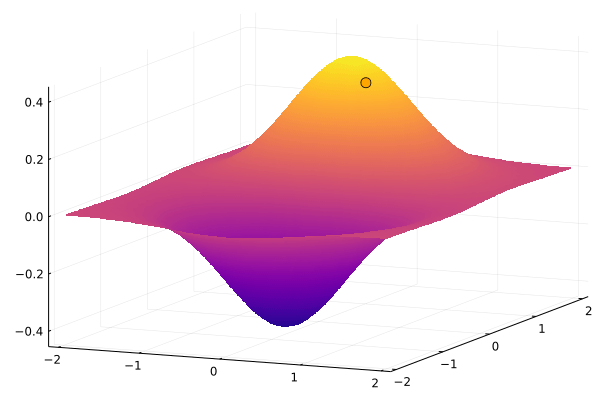

```julia
Nx=50;Ny=50;
X=range(-2,stop=2,length=Nx);Y=range(-2,stop=2,length=Nx)

function f3(x,y)
    y*exp(-x^2-y^2)
end

function df3(x,y)
    [-2*x*y*exp(x^2-y^2);exp(-x^2-y^2)-2*y^2*exp(-x^2-y^2)]
end

function u3(x,y)
    df3(x,y)
#    df3(x,y)/norm(df(x,y))
end

pas=-0.1

M0=[0.3;0.5]

P0=[M0[1],M0[2],f3(M0[1],M0[2])]

surf=surface(X, Y, f3,c=:plasma,legend=false,camera=(30,35),size=(600,400))
surf=scatter!([P0[1]],[P0[2]],[P0[3]],c=:orange, marker=:circ,markersize=6)
#surf=scatter!([0],[0],[0],c=:orange, marker=:star4,markersize=6)

anim=@animate for k in 1:25
    M1=M0
    P1=[M1[1];M1[2];f3(M1[1],M1[2])]
    surf=plot!([P0[1],P1[1]],[P0[2],P1[2]],[P0[3],P1[3]], c=:black)
    M0=M0+pas*u3(M0[1],M0[2])
    P0=P1
end

gif(anim,"surf3.gif",fps = 5)
```

```
┌ Info: Saved animation to
│   fn = D:\Users\guilhot\Documents\0MATHS\0COURS\52 OPTIMISATION\niv3.gif
└ @ Plots D:\Users\guilhot\.julia\packages\Plots\SVksJ\src\animation.jl:104
```

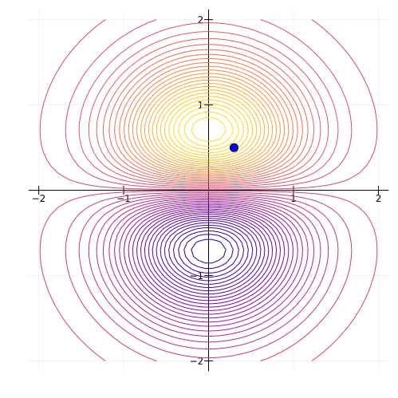

```julia
niv=contour(X, Y, f3, c=:plasma,levels=50,legend=false,
    size=(500,500),framestyle=:origin)

M0=[0.3;0.5]
niv=scatter!([M0[1]],[M0[2]],c=:blue, marker=:circ, markersize=6)

anim=@animate for k in 1:25
niv
M1=M0+pas*u3(M0[1],M0[2])
niv=plot!([M0[1],M1[1]],[M0[2],M1[2]], c=:blue, line=:arrow)
M0=M1
end

gif(anim,"niv3.gif",fps = 5)
```

## Exemple 4

Regardons maintenant le cas de :

$$f(x,y)=-3x^3+3x-y^2$$

```
┌ Info: Saved animation to
│   fn = D:\Users\guilhot\Documents\0MATHS\0COURS\52 OPTIMISATION\surf4.gif
└ @ Plots D:\Users\guilhot\.julia\packages\Plots\SVksJ\src\animation.jl:104
```

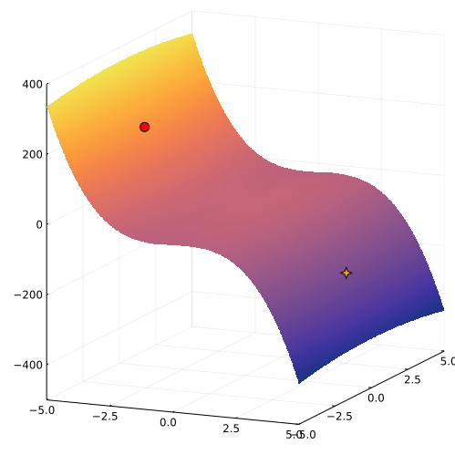

```julia
Nx=50;Ny=50;
X=range(-5,stop=5,length=Nx);Y=range(-5,stop=5,length=Nx)

function f4(x,y)
    -3*x^3+3*x-y^2
end

function df4(x,y)
    [-9*x^2+3;-2*y]
end

function u4(x,y)
#    df4(x,y)
    df4(x,y)/norm(df4(x,y))
end

pas=-0.5

M0=[-4;0]

P0=[M0[1],M0[2],f4(M0[1],M0[2])]

surf=surface(X, Y, f4,c=:thermal,legend=false,camera=(30,30),size=(500,500),
        xlims=(-5,5),ylims=(-5,5),zlims=(-500,400))
surf=scatter!([P0[1]],[P0[2]],[P0[3]],c=:red, marker=:circ,markersize=6)
surf=scatter!([4],[0],[f4(4,0)],c=:orange, marker=:star4,markersize=6)

anim=@animate for k in 1:30
    M1=M0
    P1=[M1[1];M1[2];f4(M1[1],M1[2])]
    surf=plot!([P0[1],P1[1]],[P0[2],P1[2]],[P0[3],P1[3]], c=:black,
        xlims=(-5,5),ylims=(-5,5),zlims=(-500,400))
    M0=M0+pas*u4(M0[1],M0[2])
    P0=P1
end

gif(anim,"surf4.gif",fps = 5)
```

```
┌ Info: Saved animation to
│   fn = D:\Users\guilhot\Documents\0MATHS\0COURS\52 OPTIMISATION\niv4.gif
└ @ Plots D:\Users\guilhot\.julia\packages\Plots\SVksJ\src\animation.jl:104
```

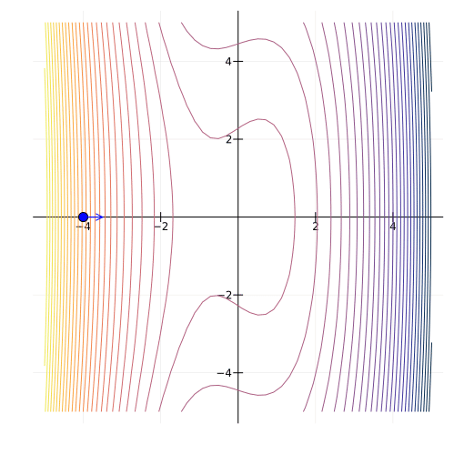

```julia
niv=contour(X, Y, f4, c=:thermal,levels=50,legend=false,
    size=(500,500),framestyle=:origin)

M0=[-4;0]
niv=scatter!([M0[1]],[M0[2]],c=:blue, marker=:circ, markersize=6)

anim=@animate for k in 1:30
niv
M1=M0+pas*u4(M0[1],M0[2])
niv=plot!([M0[1],M1[1]],[M0[2],M1[2]], c=:blue, line=:arrow)
M0=M1
end

gif(anim,"niv4.gif",fps = 5)
```